# essays_on_capital_as_a_real_god

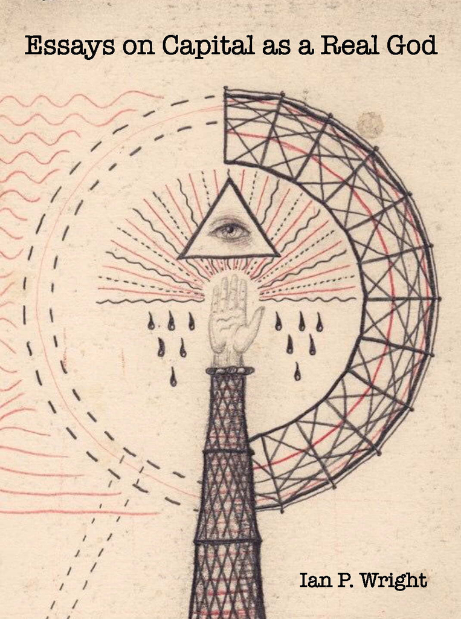

##### Adapted from https://ianwrightsite.wordpress.com/2021/11/26/essays-on-capital-as-a-real-god/ (with permission of the author)

##### Cover adapted from Harmonic Tower by [Daniel Martin Diaz](https://www.danielmartindiaz.com/)

## I. Marx on Capital as a Real God

### Introduction

There is a specific aspect of Marx’s theory of capitalism that I believe isn’t sufficiently emphasised. And that is Marx’s view that capital is an actual entity — a being with a mind of its own that operates independently from us.

And of course, when stated plainly like this, the proposition seems absurd. How can a large sum of money that is used to make profit have a mind of its own? That doesn’t make any sense at all.

But my aim, here, is to explain precisely why this proposition is not absurd, but in fact articulates the essential nature of capital, and that viewing capital as an entity is necessary to fully understand the social reality that we find ourselves in.

### Marx’s Alien Entity

Marx viewed capitalism as a semi-conscious social formation in the thrall of objective economic laws that no-one really controls. And Marx repeatedly points out that capitalism reproduces the religious mystification we find in earlier stages of history, but in new forms — such as commodity fetishism. So it’s quite typical for Marx to employ religious metaphors when discussing capitalism.

But Marx, in comments on James Mill written in 1844, says something more. After making his typical point that the essence of money is a specific kind of social practice — rather than some property of a material thing, such as gold — he then says that our social practice has become an independent, material thing — an actual entity, a “real God” — that has real causal powers. And that we are slaves to this god, and its cult has become an end in itself.

> The essence of money is … the mediating activity or movement, the human, social act by which man’s products mutually complement one another, is *estranged* from man and becomes the attribute of money, a *material thing* outside man. Since man alienates this mediating activity itself, he is active here only as a man who has lost himself and is dehumanised; the relation itself between things, man’s operation with them, becomes the operation of an entity outside man and above man. Owing to this *alien mediator* - instead of man himself being the mediator for man - man regards his will, his activity and his relation to other men as a power independent of him and them. His slavery, therefore, reaches its peak. It is clear that this *mediator* now becomes a *real God*, for the mediator is the *real power* over what it mediates to me. Its cult becomes an end in itself. [^1]

And we should make special note that Marx says a “real” god, and not an imaginary god. So Marx is not talking about the mere ideological worship of the idol of free enterprise or the market, but actual material subordination to an actually existing entity.

### Science or Metaphor?

This is not merely commodity fetishism, but a full blown Lovecraftian nightmare.

[figure not shown]

The Great One Monks - Cthulhu, by Giovani Francisco Luengo

Surely this is hyperbole? Marx’s talk of commodity production manifesting, or invoking, an “entity” that is a “real god” with “real powers” must be a poetic metaphor, which aims for dramatic impact rather than scientific precision?

We are strongly predisposed to interpret Marx metaphorically, rather than literally, because our modern, commercial culture is thoroughly secular, and we live it every day. Economics, as we all believe, is fundamentally a profane, not a sacred, endeavour. Commercial activity aims for worldly success, not spiritual enlightenment. And success depends ultimately on some mastery of the social and material world, which requires industry, experimentation, and reason — and not worship of, subordination to, and faith in higher beings. Capitalism embraces scientific rationality and technological progress, and has happily detached itself from earlier beliefs about all-powerful gods.

Plus, many of us, I hope, are hard-nosed scientists. And so we should be immediately sceptical of claims about mysterious entities that exist “outside man and above man”.

So this is the question I want to address is the following: is Marx’s “real God” really real? Is it an entity that actually exists? Or is it mere metaphor, which serves to illustrate, or dramatise, some properties of social reality? To what extent should we take Marx seriously.

Are we really blindly worshipping an alien god that controls us?

To answer this question I need to revisit some core aspects of Marx’s thought, specifically his theory of economic value, but from a new perspective, that of control theory. And by control theory I mean the scientific and mathematical theory of control systems. This new perspective will help us decide how to interpret Marx’s talk of a “real God”.

### The Affinity Of All Things

We all know that parts of reality can represent or measure other parts of reality. A ruler measures length, a thermometer measures temperature, and so on. We created these measuring devices for a definite purpose.

But the meaning of money, what it might signify or represent, is less clear. Although money first appeared over 2000 years ago, what it may represent as a symbol remains a subject of deep controversy.

To be clear, by “money” I don’t mean actual coins or notes but instead the numerical quantities we see stamped on coins or printed on notes, or stored as bits in computers, and so on. To be really precise, I should say “unit of account”. But saying “money” is simpler, as long as we’re clear about what we mean.

Now, Marx tackles the meaning of money in his famously difficult, opening chapters of the first volume of Capital. He notes that the exchange of commodities in the market implies there’s something equal, or equivalent, about them. For example, if I sell 20 yards of linen for 10 pounds, and then spend my 10 pounds on a new coat, then, indirectly, 20 yards of linen have been made equal to 1 coat by the act of exchange.

If market prices were entirely random there would be nothing more to say because this equivalence would be accidental. But although prices fluctuate they are not random. There is a strong signal in the noise. Typically, you can’t sell a pen and then buy a plane. And you can’t work for a day and then spend your day’s wages to buy a mansion. There are exceptions. But the exceptions prove the rule.

So during any period of time there are definite well-established market prices that determine the ratios in which commodities can exchange, that is are equalised, with each other. And all these exchanges are facilitated by, to use Marx’s phrase, an “alien mediator” that we call money.

### The “Magic and Necromancy” of Commodities

A quick dip into any anthropological textbook quickly reveals that humans entertain the most diverse and extraordinary beliefs about how the world works and how we should conduct our everyday lives. What some cultures consider normal, others would consider strange and bizarre.

We rarely take an anthropological viewpoint on our own culture. That’s because it’s hard to do. It requires stepping out of one’s conceptual framework, and looking at the ordinary and accepted as unusual and questionable.

So let’s take a moment to note how fantastical commodity exchange actually is.

Only dedicated occultists would dare claim that everything we see around us, all the things and activities in the world, are — despite all appearances — really the same. That 1 kg of caviar is “the same as” 1000 different people clicking on the same internet advert. Or clowning at a children’s party is actually “the same as” 200 rounds of shotgun ammunition. Or that 1 month of computing time on a high-spec machine in the cloud is “the same as” 1 tonne of potatoes. Only highly trained adepts could begin to see the truth of such counter-intuitive and magical affinities.

But we more than see the truth of it. We openly and regularly achieve it. We manifest these magical affinities on a daily basis. We treat quantities of fish eggs, human attention, clowning performances, bullets, computing time, potatoes, and a bewildering array of other things, as “the same” — because, in the marketplace, they all may be exchanged for one another, via the “alien mediator” we call money.

[figure not shown]

Mammon by George Frederick Watts, 1884-85

Magical traditions rather meekly propose correspondences between planets, minerals and human fate. But the magical operations of our modern commercial world — where every thing, activity and even future event is successfully reduced to comparable quantities of this substance we call “money” — overwhelmingly surpass, in both scale and ambition, the most deranged fantasies of the medieval grimoires. Market exchange achieves a universal affinity between all things under the sun.

It is for these sorts of reasons that Marx writes of the “mystery of commodities” with its “magic and necromancy”.

### The Economic Mysteries

Market societies achieve a titanic conceptual abstraction: every single thing that we swap between ourselves is stamped with a single quantitative property that we call exchange-value. But, rather mysteriously, no single person, no single consciousness, is responsible for maintaining the abstraction.

Marx wrote, “A commodity appears at first sight an extremely obvious, trivial thing. But its analysis brings out that it is a very strange thing, abounding in metaphysical subtleties and theological niceties” (Marx, Capital vol. 1).

So we have two economic mysteries: a ubiquitous social abstraction without any obvious content, and an abstraction without an abstractor.

To decide whether Marx’s “real God” is real or a metaphor, we need to dig deeper into the “alien mediator” that is money, what exchange-value represents, and what, if anything, maintains the abstraction.

### The Content of Value, or Abstract Labour

So let’s begin with the first mystery: what is the abstraction of exchange-value? What do those money quantities actually denote?

Marx argues that exchange-value refers to a special, common property shared by all commodities — that of being the products of labour. So caviar and clicks are the same because, to manifest them as commodities in the marketplace, requires the sacrifice of someone’s labour.

I think that Marx’s argument — for the proposition that the special common property shared by all commodities is labour — is unsatisfactory. I think Marx’s conclusion is correct, but his argument for it isn’t. But I don’t want to take a detour into this debate. So let’s simply accept this at face value for now.

Marx then says that the common property cannot be specific kinds of labour — because fishing for caviar, or writing advertising software, or clowning, or making bullets — are very different activities.

The act of exchange abstracts from the individual peculiarities of different labouring activities, leaving something common to all of them, which Marx calls “human labour in the abstract”, or abstract labour. Commodities, according to Marx, have economic value “only because human labour in the abstract has been embodied or materialised in it”.

[figure not shown]

Soul Groups by Kazuya Akimoto

Now, we have to be careful with the term “embodied”. Marx doesn’t literally mean that abstract labour inheres within the material body of the commodity. Abstract labour is not a physical property of a thing. What he means is that some definite fraction of the total labour time of society must be used-up, or expended, to produce the commodity and bring it to market.

So abstract labour is not concrete labour, not a specific type of labouring activity, but something else, something deeper and more general. As Marx states, abstract labour has “the character of the average labour-power of society”. So a good first approximation is to think of abstract labour as denoting the causal powers of the typical or average worker. That isn’t quite right, but it will do for now.

So, according to Marx, the titanic abstraction achieved by commodity exchange refers to a specific content, which is a property of the material world that he calls abstract labour.

### How Do We Measure Abstract Labour?

Marx then immediately asks the obvious question, “How, then, is the magnitude of this value to be measured?” and he answers, in a seemingly straightforward way, that it is measured “by its duration, and labour time in its turn finds its standard in weeks, days, and hours.” So we’re talking about units of time.

We might suppose, therefore, that we can immediately pull out our stopwatches and start measuring the amount of time people spend working, and then correlate our measurements with the prices we observe in the market. Because if prices really do represent labour-time then we should, in-principle, be able to scientifically verify this claim.

But that would be too hasty. Before we can even consider empirically verifying Marx’s theory of value, we need more clarity on what that theory actually is.

Now I’m not sure how deliberate this is, especially as I read Marx in translation. But it might be noteworthy that Marx does not ask, “How should we measure quantities of abstract labour?”, and neither does he answer by saying that “we can measure it by its duration”.

And that’s because we don’t measure abstract labour. Something else measures it.

This property of Marx’s theory — that money refers to labour time in virtue of our collective, social activity and independently of our thoughts about it — is radically different from the classical political economy of his day, and also modern economic theory.

The abstraction is not ours because our cognition is not performing the abstraction. We are not the abstractor. Instead, the mysterious abstractor is taking the measurements about labour time and connecting the form of value, which is money, to its content, which is abstract labour.

So, as scientists, our first job isn’t to start measuring labour time. Our first job is to understand what the abstractor is, and how it connects its abstraction to its world. We need a theory of this abstracting entity, and its powers, before embarking on empirical verification.

### Who or What is the Abstractor?

So we have a partial answer to the first economic mystery. The abstraction of exchange-value, or more plainly money, represents “abstract labour”. So let’s turn to the second mystery: who is doing the abstracting? Who or what is the mysterious abstractor?

In fact, Marx has already told us who it is. Sometimes mysteries hide in plain sight. The big clue is Marx’s choice of the title for his magnum opus. The abstractor is what Marx calls “capital”.

But the term “capital” can mislead. First of all, it gets us thinking about large sums of money. A capital sum. But capital is much more than that. And, second, modern economic theory has reduced the term “capital” to a vanilla accounting term that mixes-up, in a confused way, capital equipment with large sums of money.

But capital, for Marx, is first and foremost a social practice. Capital denotes a collection of activities that certain people regularly do embedded within a system of property rights, contracts, and coercive power. Capital is a circuit, where an initial capital sum is “invested” in production, and then typically returns with a profit increment. Capital enlarges itself, whenever it can. This circuit is mediated not only by money, but also economic production itself, including the disciplining and exploitation of workers.

Marx’s standard language — of capital, of social relations of production, circuits of accumulation, and so on — doesn’t fully evoke what’s really going on, and I think that’s why he often turned to religious language.

So instead of saying “capital” I’m also going to say “the controller”. Because capital is a control system, not merely in the political sense, but in the more profound and scientifically important sense of being a negative feedback control system. Capital is literally a controller. So if capital is a controller, then how does it work, and what does it control?

### Control Systems

Scientific progress sometimes consists in organising a whole range of diverse phenomena under a single principle. The emergence of cybernetics, in the early 20th Century, was just such an event.

The core idea of cybernetics is that many different kinds of systems — be they mechanical, physical, biological, cognitive, or social — are types of control systems that exhibit a particular kind of causal structure, the negative feedback control loop.

And it turns out that negative feedback control explains how parts of reality can control, and therefore refer to, other parts of reality.

All negative feedback control loops have four main components: (i) an internal goal-state, (ii) a sensor that measures some property of the external world, (iii) a comparator that compares the sensor reading to the goal state, and (iv) an effector or action system, which changes the world to move closer to the goal state.

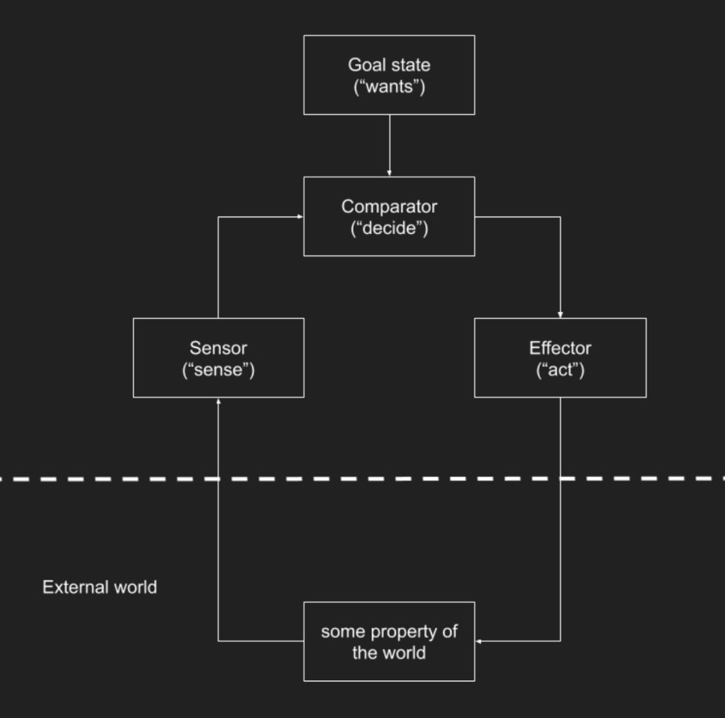

Control System Diagram

In fact, all homeostatic and goal-directed systems in nature conform to this causal template. Different examples just implement the components of the control loop in different ways.

And, perhaps surprisingly, there is a very significant control loop, hiding in plain sight, which affects every aspect of modern life in the most profound and intimate manner.

### Capital as a Negative Feedback Control System

The basic unit of production, where capital meets labour to produce goods and services, is the capitalist firm. And every profit-maximising firm is owned by a private capital.

Capitalists extract profits from firms. They can spend only a fraction of their profits on luxury consumption. Because if the rich spent all their profit on luxuries their capital will rapidly diminish and expire, compared to competing capitals who invest their profit in further profitable activities. Profit income must be reinvested in order to make more profit. This is the prime directive for anyone who possesses a capital sum of money.

Owners of capital — that is capitalists — can’t put all their eggs in one basket. That’s too risky because firms can go under, or assets that store value might depreciate. So capitalists spread their risk by owning a portfolio of investments with different risk profiles.

A typical portfolio will consist of cash held in different sovereign currencies, government, municipal and corporate bonds, shares in different companies, from risky start-ups to blue chips, and all kinds of income-producing assets, such as land and housing. Basically anything that might yield a higher than average return.

Each individual capital must aim to maximise the return over its portfolio. If it fails it will diminish in size relative to other capitals, and eventually cease being a capital at all.

And it’s right here that we again find the causal structure of a feedback control system. An individual capital — when we consider it as a social practice mediated by a privately owned large sum of money — also has its own goal state, sensory inputs, decision making, and ability to act upon the world in which it is embedded.

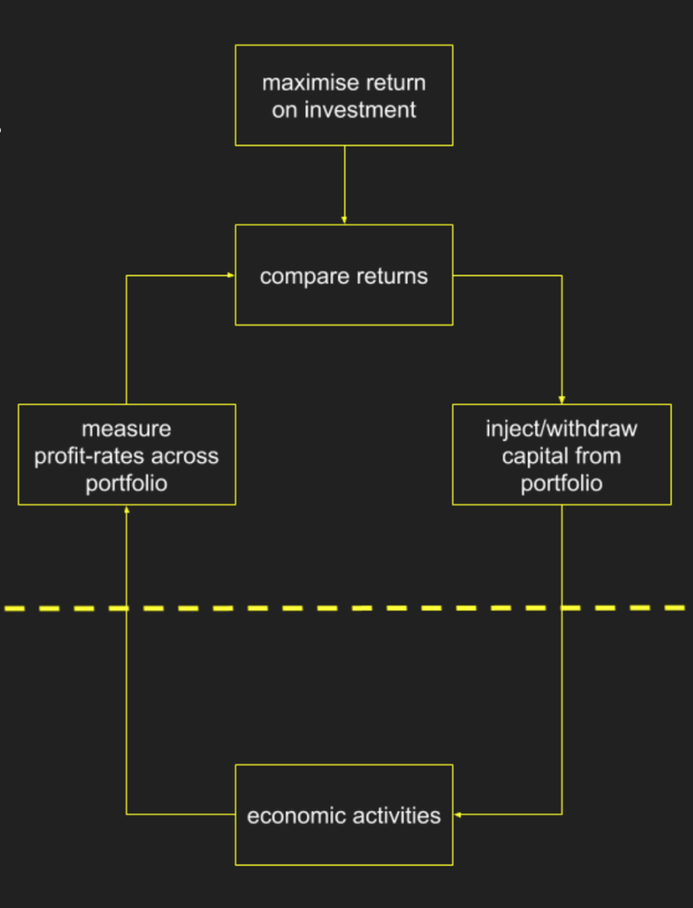

Capital As Controller Diagram

Let’s take each of these in turn. (i) The goal of an individual capital is to maximise the average return from every dollar (or pound) invested. (ii) The “sensory inputs” are the different profit-rates earned across the portfolio. (iii) The capitalist, or the financial experts they employ, compare the different profit-rates, and (iv) the feedback loop is closed by actions that withdraw capital from poorly performing investments, and inject capital into high performing investments.

This control loop manifests as an insatiable and ceaseless search for high returns.

Capital doesn’t care how its money is actually used in production. It entirely abstracts from all concrete activities. The only thing it can sense, compare and use is abstract value.

So the commanding heights of the global economy consists of an enormous ensemble of individual capitals, each manically scrambling for profit, reacting to the signals of differential returns received from its tendrils that extend to every productive activity under its rule, continually injecting and withdrawing capital to and from different industrial sectors and geographical regions. The entirety of the world’s material resources, including the working time of billions of people, are repeatedly marshalled and re-marshalled away from low and towards high-profit activities. In the space of months, entire industrial sectors may be raised up, relocated, or thrown down.

# Capitalists are Possessed, Mere Machine Components of Capital

What about the individual people who participate in this social practice? Surely their individual consciousness, their ideas, and their behaviour matter, and make a difference?

To a certain extent they do of course. But individuals come and go, but capitals live much longer than any individual human. The people controlled by the capital — that is the workers that supply labour to firms, and capitalists that exploit them and extract profits — are mere replaceable components in the control loop, mechanically performing prescribed functional roles.

For example, Marx writes in Capital, that:

> “to classical economy, the proletarian is but a machine for the production of surplus-value; on the other hand, the capitalist is in its eyes only a machine for the conversion of this surplus-value into additional capital.” [^2]

We often say that a capitalist possesses capital. But it is more accurate to say that capital possesses them. Capitalists are the human face of an inhuman intelligence with its own logic and its own goals.

[figure not shown]

Mr. Kraken by Olly Jeavons

> “In bourgeois society capital is independent and has individuality, while the living person is dependent and has no individuality” (Communist Manifesto). [^3]

### The Demonic Power of Capital

Bigger capitals enjoy the advantage of larger portfolios, which spreads risk. In consequence, capital tends to concentrate in a few hands. So we find a large number of small capitals, and a very small number of astronomically large capitals, which earn profits that dwarf the GDP of many nation states. The scale and power of some capitals is truly titanic.

And these titans are so much in control, that they are out of control. Again, a quote from the Communist Manifesto:

> “Modern bourgeois society, with its relations of production, of exchange and of property, a society that has conjured up such gigantic means of production and of exchange, is like the sorcerer who is no longer able to control the powers of the nether world whom he has called up by his spells.” [^4]

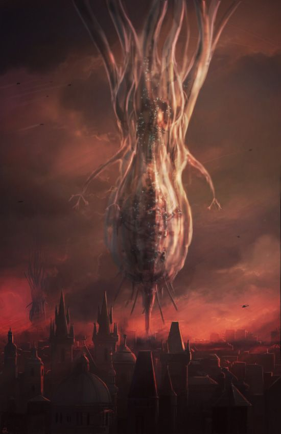

Medusa by Rado Javor

In mythology, demons are anarchic, out-of-control entities that cause us harm, through tormenting us or through possession. Not only is the power of capital titanic, it is demonic. Let’s just briefly consider a few examples.

Every day millions of workers, around the globe, have no choice but to sacrifice their time, and their vitality, to produce new profit for the autonomous controllers. No matter how hard, long or efficiently we work, the imperative to work remains.

Why? Because every labour-saving technical innovation takes the form of profit, which is then captured by individual capitals, and immediately re-injected into the material world to animate new activities for further profit. This is why, despite huge advances in automation, the working day remains as long as ever.

Take another example: the logic of capital demands maximum profit extraction from firms, and that means minimising wages. Those possessed by capital live an exalted existence. But the world’s dispossessed must feed, clothe and maintain a home with an average income of about 7 pounds a day.

Another example: it’s better to be exploited than not exploited. We are subject to the whims of the business cycle and periodic crises of accumulation. Recessions regularly throw large numbers of people out of work, through no fault of their own. Suddenly bills can’t be paid. Families are thrown onto the street, as happened in the US during the 2008 mortgage crisis, and is happening again now.

Why? Because individual capitals are almost blind. They see only differential returns across their portfolios. And returns may be good even if unemployment is high, or human misery spills onto the streets. Capital does not care.

Another example: capital deals in abstract value, and things that are not owned, which aren’t bought and sold, therefore have no value to it at all. So the material wealth of nature — the land, the oceans, and the atmosphere — is relentlessly plundered without any regard for the consequences.

Capital destroys us, and the environment. The endless production and profit-making cannot stop, because each individual capital must compete to survive. Marx summarised the prime directive of capital as:

> “Accumulate, accumulate! … reconvert the greatest possible portion of surplus-value … into capital! Accumulation for accumulation’s sake, production for production’s sake: by this formula classical economy expressed the historical mission of the bourgeoisie”. [^5]

So all the autonomous control loops have the single-minded goal of extracting profit from the world’s activities. If an activity fails to satisfy this goal, then the controller withdraws its capital, and the activity stops.

So at the apex of the economy we have a competing collection of identical controllers — with an atavistic, low level of demonic intelligence — which inject and withdraw a social substance that appears to possess the magical power of animation, of bringing things alive, of creation; but also appears to possess the power of annihilation, of suffocation, of bringing things to an end, of destruction.

We are definitely not in control. And something else definitely is in control.

### Animism

So what are we really talking about now?

We’re saying that a new kind of supra-individual control system emerged, quite spontaneously, from our own social intercourse, and then — in a very real sense — has taken on a life of its own, turned around, and started controlling us.

Capital in a scientific, not a metaphorical sense, is a control system. And it is capital, as a control system, that ultimately creates and maintains the abstraction we call exchange-value. Capital is the abstractor.

But before we can fully explain how that happens we need to take some moments to explore the relationship between control systems and primitive forms of cognition.

So, the earliest humans were at the mercy of nature. At any time, the harvest might be ruined, or illness or injury might strike. The earliest theoretical framework to explain the capricious forces of nature seems to be animism.

[figure not shown]

Green Man Linocut by Alan Rogerson

Animism is the belief that all natural phenomena — such as the weather, geography, plants, trees, animals and so on — are ultimately controlled by an autonomous, living entity with human-like agency. Early humans believed that different clusters of empirical phenomena were controlled by conscious spirits, with minds of their own.

Marx gives us a very brief sketch of this history of religion in Part 3 of “Anti-Duhring”, which begins with a discussion of animism. The weather gods, sea gods, sun gods, moon gods, gods of illness and healing, and so on, are the hidden actors, or ultimate cause, of uncontrollable events.

Now, if you believe gods are invisible hands that affect your life, then it makes perfect sense to appeal to them — by praying, or giving them gifts, or building temples to worship them. The power and majesty of the ancient gods was the perverted expression of the powerlessness and misery of early humans.

### The “Real God”: Beyond Commodity Fetishism

Today, we enjoy a great deal more control over our lives compared to our ancestors. And this material progress, in itself, has gradually removed the material basis for animistic belief systems.

Many of the causal powers of the ancient gods and demons, have, one by one, been explained by science. And so they lost their power. Instead of a ragbag of pagan gods, with special powers and domains, we have scientific fields with their own theories and technical terminology.

Of course, animistic religion persists in capitalist society, but typically well outside the mainstream. As Marx explains, in his short sketch:

> “At a still further stage of evolution, all the natural and social attributes of the numerous gods are transferred to one almighty god, who is but a reflection of the abstract man.” [^6]

So modern mainstream religions, such as Islam and Christianity, talk of one, all-encompassing god, who is remote and abstract, and unlike the animistic deities of old, typically doesn’t interfere in everyday phenomena.

Marx then turns to modern society, and makes the important point that capitalism does not abolish the material conditions that give rise to religious beliefs:

> “in existing bourgeois society men are dominated by the economic conditions created by themselves … as if by an alien force. The actual basis of the religious reflective activity therefore continues to exist … It is still true that man proposes and God (that is, the alien domination of the capitalist mode of production) disposes.” [^7]

Precisely because capital is in control, and not people, then the “actual basis” of “religious reflection” continues to exist.

Famously, in the first chapter of Capital, Marx explains how market exchange necessarily generates commodity fetishism — which is the illusion that economic value is a natural or material property of commodities. So inanimate objects — especially forms of money, such as gold — fetishistically appear to have special powers in-and-of themselves.

But Marx’s talk of a “God” that we “propose” to and it “disposes” takes us beyond commodity fetishism. Marx is pointing to the fact that economic laws have god-like powers that operate independently of us, and control and dominate us, like forces of nature.

Is Marx therefore committing an animistic fallacy by suggesting that capital, as an independent entity, is a “real God” with “real powers” that as a mind of its own?

Once we understand capital to be an autonomous control system, then the answer is a plain “no”. A negative feedback control loop has all the basic elements of cognition: it in fact senses, decides and acts. A qualified kind of animism is entirely appropriate here.

Of course, the sensing, thinking and acting cycle of an individual capital is quite unlike that of an individual human being. Nonetheless, both pursue distinct goals, and both have the power to make things happen. One control system consists of neurons, muscles and organs; while the other consists of social practices, belief systems and the exchange of a value substance.

So, speaking animistically, a spirit, or deity, indeed controls capitalism. This god can shatter itself, and appear at multiple times in multiple places. And it can combine with versions of itself, to aggregate into bigger and more powerful incarnations. It can possess humans, and control them, by forcing them to work, or forcing them to accumulate. This entity directs social activity by giving and withdrawing its magical substance, which we call value. We sacrifice ourselves to it, we appease it, and we hope it will favour us.

[figure not shown]

Kali by Johfra Bosschart, 1976

All these statements are scientifically accurate. They are not metaphors. In fact, adopting a more animistic theory of modern capitalism would, counter-intuitively, constitute scientific progress.

Let’s now take this animistic point of view and enquire what capital, as a god-like entity, tends to think about. What are the contents of capital’s cognition?

### What Does the Real God Control?

Sometimes it’s obvious what a particular control system controls, because we designed it. For example, we know that a thermostat controls room temperature. In consequence, the electrical control signals that flow within the thermostat refer to temperature.

But the vast majority of control systems are not designed by people. Nature is stuffed full of them, from simple homeostatic mechanisms to incredibly complex animal brains. These systems evolved, without a designer, and therefore we have to work harder to determine what they control, and what their internal representations may, or may not, represent in their environment.

I will skip the details of a scientific theory that determines what controllers in fact control. It’s not a simple story [^8]. I think the complexity of that story partially explains why Marx’s argument that abstract labour is the substance of value, in the opening chapters of Capital — chapters that he famously worked and re-worked, that Engels joked bore the marks of Marx’s painful carbuncles — is not entirely satisfactory. Marx had stumbled upon a hard problem that couldn’t be fully solved with the conceptual tools of his time.

So, instead of going down this rabbit hole, I’ll instead jump to the conclusion and simply state what capital, as a control system, in fact controls.

We already know that capitals, both big and small, are intimately connected to the process of production. The capitalist firm borrows capital to buy inputs and means of production, and hire workers. Workers supply concrete labour to produce use-values for sale in the market.

Now, the controller judges all the different concrete activities occurring across its portfolio in the same way: which activities yield above-average returns, and which do not? The controller rewards firms that make comparatively high profits with new injections of investment; but punishes firms that make comparatively low profits, or losses, by withdrawing its capital. These monetary rewards and punishments flow down, through firms, into the labour market, and reward concrete labour by the payment of wages, or punish by withdrawal and unemployment.

In this very real sense, capital wants specific kinds of concrete activities, and does not want other kinds. The kinds of activities it wants are those that yield above-average profit. Capital is therefore controlling us. And it controls how we spend our time.

### Abstract Labour: The Kind of Labour That Capital Wants

So capital wants labouring activities that yield profit. Simplifying, we can identify two essential properties that concrete labour must possess in order to yield profit.

First, it must be useful to others, that is produce commodities that can be sold in the market. No-one will buy a coat with three arms.

Second, it must have above-average efficiency; in other words, a firm makes more profit if it uses-up less labour-time than competitors that produce the same commodity.

And this is why, just after Marx first introduces the concept of abstract labour, he immediately points out that only socially necessary, and useful, labour counts as abstract labour.

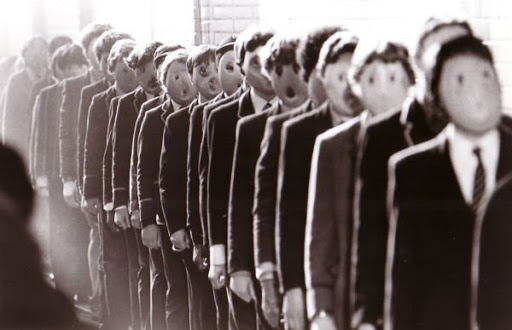

We don’t need no education, Pink Floyd

Capital does not want workers to spend time smelling the roses with their family and friends. That activity doesn’t yield saleable use-values. Neither does capital want workers to slack on the job, or become ill. Slacking or illness isn’t efficient. Capital, if it completely had its way with us, would have us spend all our time labouring in the firm at the highest possible intensity, continually striving to out-compete other workers in the labour market. This is the kind of behaviour that capital wants.

So capital controls concrete labour, the real labouring activities of the working population in all their diverse manifestations. And capital controls actual labour-time, actual clock times of real people doing real things. It is capital itself that holds a metaphorical stopwatch in its hand, measuring and accounting, and judging and condemning; always on the look-out for the slightest slacking off or insubordination.

And the goal of capital is to convert concrete labour into abstract labour, into the kind of labour that both fits into the division of labour, so it can be exchanged against other labour, and into the kind of labour that fully sacrifices itself to capital, gives itself up as tribute, in order to yield profits for the capitalist firm, and ultimately the controlling, dominant capitals that stand behind them.

In other words, “abstract labour” is manifested, brought into reality, by capital itself. *Maximising profit is identically the process of maximising the manifestation of abstract labour out of concrete labour*.

This is why Marx says that only abstract labour “creates value”. Concrete labour may or may not create value. If it doesn’t, it isn’t abstract labour, and capital as a controller quickly works to eradicate its existence, by withdrawing capital from the firms that employ it.

### Capital as Egregore

So capital is a controller that employs a form of value — money — to control the content of value — which is our labour time. The form and the content are bound together, linked semantically in a relation of representation to referent, by the lawful regularities instantiated by generalised commodity production.

As we have seen, control systems instantiate the basic elements of cognition. They in fact have internal representations that refer to the world they act in. In consequence, *Marx’s theory of value is fundamentally a theory of an alien cognition that controls us*.

No wonder he wrote of the necromancy of commodity production because only the religious, magical and occult traditions in our history have adequate concepts to express our predicament.

The occult concept of an egregore is useful here. An egregore is a non-physical entity that exists in virtue of the collective ritual activities of a group yet operates autonomously, according to its own internal logic, to materially influence and control the group’s activities. The group creates the egregore, and the egregore creates the group, in a self-reinforcing feedback loop.

Marx, in his Economic and Philosophical Manuscripts of 1844, explicitly calls out this reciprocal relationship between a god and its people, between a cult and its egregore.

> “as a result of the *movement of private property* … we have obtained the concept of *alienated labor* … But … it becomes clear that though private property appears to be the reason, the cause of alienated labor, it is rather its consequence, just as the gods are *originally* not the cause but the effect of man’s intellectual confusion. Later this relationship becomes reciprocal.”

The ritual activities of the initial capitalist cults were materially so successful they rapidly metastasised and, in a few centuries, engulfed the world. What is universal becomes the unnoticed background. So the egregore, in our society, is hard to see. It hides in plain sight. We refer to it, of course, but obliquely, using soporific names, such as “the economy” or “the markets” or “capital”. But Marx pointed to a better name for it, one designed to wake us from our slumber: *A real God with real powers*.

### An Alien Cognition that Binds Value Form to Labour Content

So capital is an egregore. Not metaphorically, or ironically, but actually. Capital is a being, an autonomous entity, with primitive thoughts about us. Money is how it measures us, and money is how it commands us. Capital is an alien cognition that acts in the world to bind the form of value to its content.

So now we know what the abstractor is. And now that we have a clearer grasp of the core structure of Marx’s theory of value it becomes much easier to spot misinterpretations of it.

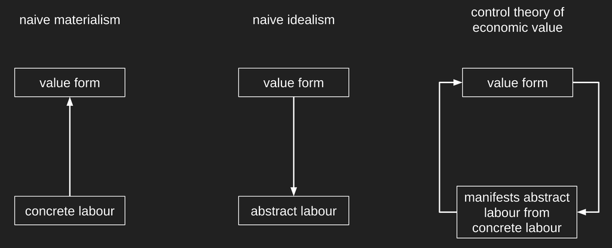

Form and Content Diagram

There are misinterpretations that emphasise the content at the expense of the form. Marx’s theory is not at all like the naive materialism we find in classical political economy, or modern Sraffian interpretations of Marx, which posit one-way causation from concrete labour-time to money prices. Instead, we must think about feedback loops, about two-way causation, from content to form, and from form back to content.

But there are other misinterpretations that emphasise the form at the expense of the content.

Clearly, Marx’s theory is an objective theory of value. Despite the pretensions of subjective utility theories of value we cannot collectively wish planes to be cheaper than pens. We are not the dominant controller, we are the controlled. The individual consumer is not king.

But more sophisticated variants of idealism also misinterpret Marx’s theory. Some Marxists think capital dreams about abstract labour, that abstract labour is an invention of the capitalist system, which doesn’t actually refer to something existing independently in objective reality. This reduces Marx’s theory to a postmodernism parody of ghostly and ideal forms.

In these misinterpretations the form has no content. And so money doesn’t refer to any property that exists independently of it. The form creates an illusory content. In this view, abstract labour may indeed have real effects, in the way that belief in an Father Christmas may cause people to offer cookies and milk, but it doesn’t really exist.

This may seem sophisticated but ultimately it reduces to value nihilism, where there are only prices, and there is nothing hidden behind them.

But Marx’s theory is essentially about the control of concrete labour time, the actual objective working conditions of millions of people. Any interpretation of Marx that claims abstract labour cannot be measured independently of markets and prices, or cannot provide a definition of the content of value without relying on magic coefficients that depend on prices — has gone awry.

Of course, like any entity, capital’s thoughts may not perfectly reflect, or represent, the reality in which it is embedded. However, if a control system successfully controls then its internal representations will bear a truthful correspondence to reality. And capital is a supremely successful controller.

And, ultimately, this is why Marx’s value claims can be empirically verified: labour is already disciplined to be efficient and useful. And so the majority of concrete labour is already abstract labour. In consequence, if we pick a group of 50 workers randomly they will approximate the value-producing power of 50 units of abstract labour. Take larger aggregates and the approximation only improves.

Taking out our stopwatch won’t work at the level of an individual worker because there’s no guarantee their concrete labour will ultimately count as abstract labour. But our stopwatch will measure abstract labour if we collect sufficient samples. As Marx stated, abstract labour has the character of the average labour-power in society. So the control success of capitalism means we can measure quantities of abstract labour before that labour is equalised and homogenised in the market.

An analogy might help here, because this is quite a subtle but important point.

An ethologist, studying the behaviour of an animal in the wild, can’t truly get inside the animal’s head and see the world through its eyes. The ethologist can never fully know what it’s like to be a bat. But nonetheless ethologists have developed detailed theories of echolocation, and how a bat’s cognition represents its environment. In a similar way, we are studying the behaviour of an autonomous entity, called capital, with an alien cognition. Abstract labour is its concept, not ours. But we can form a concept of abstract labour that corresponds to its concept of abstract labour. After all, we, the controlled, and it, the controller, all live in the same world. And we can both talk about, and represent, an objective property of that shared world.

And what is that objective property? We can now refine our initial, approximate definition of abstract labour. It is not just average labour, or the common causal powers of human labour. It is something more specific, something more historically determined and therefore contingent.

Abstract labour is a collection of causal powers possessed by human labour that can manifest as an ability to produce an endless variety of useful things for others, to make profits by working harder or longer, to improve techniques of production so more may be produced with less, and to out-compete others in a ceaseless scramble for profit. If we workers lacked these causal powers then capital would fail to mould us into the value-creating, homogeneous units that it wants.

### Capitalism as an Occult Mode of Production

Capital isn’t a huge sum of money but a definite set of social practices that instantiate a control system. Each capital is a controller that acts independently of any individual human consciousness. In this very real sense, each capital is an entity, a being-for-itself. And each capital has primitive forms of cognition: capitals continually sense, decide and act in order to achieve the overriding goal of maximising returns. This is not a metaphor, but science. Marx’s “real God” is really real.

Marx reminds us that capitalism does not abolish the material conditions that give rise to magical and religious thinking. Commodity fetishism is rife, and confusions abound. For instance, modern economic science has successfully repressed Marx’s theory of value, and the theft-based nature of capitalist property relations, yet has proved itself incapable of formulating an alternative theory of economic value. The economic mysteries remain.

To add to the confusion and mystification, capitalist ideology promotes the idea that our commercial culture is fundamentally a rational and secular endeavour. But the opposite is the case. The rationality of capitalism is not human but alien, and we do not control it, but it controls us. Capitalist ideology refuses to see the “real God” that is capital, and our subordination to it. The god is real, but hidden, hiding in plain sight. And in this sense, *capitalism is an occult, not a secular, mode of production*.

The value form, the titanic abstraction that permeates every aspect of our lives is, in a sense, the primitive language of the controller. It sees and judges our activities in terms of abstract value, by comparing differential profit-rates across its portfolio. But it also commands our activities using abstract value, by injecting and withdrawing its substantial being, which is money. Capital works to mould, shape, and discipline the total labour-power of society into the specific form of abstract labour, which is labour that gives itself up, utterly and completely, as tribute to capital.

So the value form participates in both measuring labour time, and also commanding labour time. We shouldn’t be surprised that *the value form also has imperative semantics*. Money doesn’t merely participating in measuring but it also commands. Generalised commodity exchange has no conscious planner or plan, and therefore the command and control necessary to organise the division of labour is achieved through the allocation of capital, the transmission of money and the structure of prices.

Capital commands concrete labour time to manifest as abstract labour time, and therefore brings into being what is already latent within us. But capital intensifies and perfects only a part of us. We are more than merely creatures able to manifest abstract labour. We have the power to do much more than merely produce useful things by working intensely for long hours. So, despite capital’s rule we resist, and find places and moments where we can be more fully ourselves. But capital does not want us to play, learn, explore, care or give freely. Capital wants us to produce — endlessly. And therefore we, under the rule of capital, are reduced to shadows, mere narrow abstractions, of what we could be.

*We are the abstracted, and it is the abstractor*.

### Slaves to the God Capital

Allow me to finish with a very blunt analogy. Cows can do lots of things. But all we care about is that they produce as much milk and meat as possible. And so we breed them, inject them, rear them, and control them to do only that. Sometimes their udders are so distended by excessive production they tear, split and spill.

We are cattle to capital. We too have become distorted and disfigured by its universal rule. It brands us as abstract labour. But we are also concrete individuals. The form does not exhaust the content. And this seemingly innocuous non-identity between form and content is the fundamental reason why, one day, we will escape from capital’s rule.

## II. Dark Eucharist of the Real God

### Introduction

Capitalist society, when it reflects upon itself in the mirror of social theory, sees a vision of a secular and rational mode of production not without blemish but ultimately shaped by the pragmatic yet noble pursuit of material progress. In contrast, earlier historical epochs, when they gazed into the mirror, became enchanted by the glittering reflection of a pantheon of god-kings and super-human deities. In such circumstances the direction of history was partially governed by a great intercourse between peoples and their gods. But we moderns, more mature and more fully conscious, gaze with unencumbered clarity at the true reflection of our own humanity, now alone but free of mystification. We collectively although confusedly make our own history without relations with the beyond. For we, unlike our less enlightened precursors, have rid ourselves of all enchantment.

> “The reform of consciousness consists only in making the world aware of its own consciousness, in awakening it out of its dream about itself, in explaining to it the meaning of its own actions. Our whole object can only be - as is also the case in Feuerbach’s criticism of religion - to give religious and philosophical questions the form corresponding to man who has become conscious of himself.

> Hence, our motto must be: reform of consciousness not through dogmas, but by analysing the mystical consciousness that is unintelligible to itself, whether it manifests itself in a religious or a political form. It will then become evident that the world has long dreamed of possessing something of which it has only to be conscious in order to possess it in reality. It will become evident that it is not a question of drawing a great mental dividing line between past and future, but of realising the thoughts of the past. Lastly, it will become evident that mankind is not beginning a new work, but is consciously carrying into effect its old work.”

> Marx to Ruge, Kreuznach, September 1843

Our reflection flickers in the mirror. Suddenly a dark presence looms behind us. We lock our eyes upon it in horror. But it has gone. There is nothing there. We must have been mistaken. Our modern world has no room for such things.

### Part One: The magic of the Eucharist

[figure not shown]

Call of Cthulhu by Francois Lunet

#### Summoning Spirits

Every day millions of Christians congregate in churches across the globe to perform the sacred ritual of the Eucharist. Ordinary bread and wine transform into the flesh and blood of Christ.

The Eucharist is a summoning ritual and therefore shares similarities with the equally ancient technique of Solomonic magic. The Babylonian Talmud, composed around 500 AD from earlier oral sources, describes how King Solomon, ruler of the ancient Kingdom of Israel, summoned the Prince of Demons to help build his Temple.

Over the centuries, Solomon’s magical techniques spread far and wide, occasionally surfacing from subterranean transmission to appear in written form, such as antique magical papyri, medieval grimoires, and in the occult literature of the modern period.

Christianity, from its earliest days, has rejected any identification with the magical practices of earlier and competing religions. Christian rituals are considered holy, not magical. The New Testament mocks the trickery of Simon the Sorcerer. Christ’s miracles, in contrast, are real.

[figure not shown]

The Last Supper, Juan de Juanes, 1562

#### The Divine Source of Evocatory Magic

However, the ability of ordained priests to summon Christ, and the ability of occult magicians to summon angels and demons, derive from the same source, which is God.

Christ, in the New Testament, exorcises a demon from a man into a herd of swine. The possessed pigs then go mad and drown in a lake. And Christ, during the Last Supper, anticipating his death on the cross, shared bread and wine and proclaimed, “This is my body … this is my blood.” Christ’s utterance instituted the ritual of the Eucharist for His embryonic Church, the assembled first apostles, in order that His priesthood would not end with His death, but endure for eternity.

The Testament of Solomon, dating from around the 2nd Century AD, describes how the Angel Michael, an emissary of God, gave King Solomon a magical ring stamped with God’s seal in the shape of a pentagram. The magical ring gave Solomon the power to command spirits.

God, being omnipotent, quite naturally has the power to command lesser spirits. And he occasionally grants this power to humans.

[figure not shown]

Dr John Dee and Edward Kelly summon a spirit in an English cemetery. Mathieu Giraldo, Histoire Curieuse et Pittoresque des Sorciers, Paris 1846

#### The Science of Evocation

The Eucharist and Solomonic magic, as forms of evocatory magic gifted from God, share techniques in common.

Both priests and magicians ritually cleanse, and practice sexual abstinence, prior to the evocation. Both wear special garments that have been blessed and magical talismans, such as a metal cross, or a lamen, hung from the neck, which ward off malignant spirits.

The priest will speak words of consecration over the bread and wine. The magician, within the protection of a magic circle, recites spells, barbarous names, and calls for the aid of thwarting angels. The words are magical due to their divine provenance and transform both priest and magician into conduits of divine power.

Spirit summoning is not to be taken lightly. Spells must be uttered with solemnity and accuracy, and accompanied by precise ritual movements, such as crossing oneself, or gesturing towards the principal directions. The right tools must be deployed. For example, priests of the Christian Orthodox church theatrically wield a hexapterygon, which is a metal staff with a six-winged angel attached to its end, and Solomonic magicians use an iron wand, or a specially forged sword, or a black-handled knife, preferably one previously used to kill a man. These magical instruments help “pin down” the spirit once summoned.

A difficulty of working with spirits, compared to other substances, is that they are typically insubstantial. In consequence, a physical receptacle, or *spiritus loci*, is required for the spirit to manifest into. In the Eucharist the bread and wine plays this role. In Solomonic magic, a Triangle of Art, or brass vessel, incense smoke, or a black mirror, will constrain the spirit to manifest to our ordinary senses.

The moment of manifestation, or epiklesis, can be more or less dramatic. In the Eucharist the summoning is, barring a miracle, always successful. The ordinary bread and wine invariably transform into the flesh and blood of Christ. In contrast, demon summoning is much less reliable, and can fail despite meticulous preparation. Epiklesis, if it does happen, can therefore be more dramatic: the demon a felt, dread presence, or visible in a black mirror, or less frequently fully substantial poised malevolently outside the circle.

The holy sacraments — the transformed bread and wine — are the substantial presence of Christ and therefore deserve the greatest respect and attention of the faithful. The sacraments may be held aloft, or sometimes displayed in a magnificent, ornamental monstrance. Demons are of course dangerous, and not to be trusted. They may fulfil a wish but in a manner that harms the magician. So wishes must be very carefully stated in the form of a binding magical contract. And demons must be given the proper license to depart at the close of the ceremony, otherwise they may linger with dire consequences.

[figure not shown]

Christ, God incarnate, crucified. Photo by Alem Sánchez

#### God’s Sacrifice

Although the Eucharist and Solomonic magic are both types of spirit summoning the rituals differ in their meaning and significance.

Solomonic magic, from the earliest written examples from around 300 BC, is a method to coerce a hierarchy of spiritual creatures. The Eucharist has no element of coercion. For the Eucharist is a holy communion, a uniting in friendship. So we have nothing to fear — no need for protective circles, or carefully worded magical contracts. Because the Christian God, we are told, bears us no ill will, in fact loves us with a love beyond our imagining.

The Christian altar, in the context of the Eucharist, is a sacrificial altar. Christ, the evoked spirit, does not manifest to do our bidding, but to remind us of His supreme self-sacrifice. God allowed Christ to be put to death by the Roman authorities. The crucifixion was God’s loving self-sacrifice for us. The Eucharist therefore is not merely spirit evocation but also the re-enactment of a sacrificial rite.

The ancient Greeks and Egyptians killed huge numbers of sheep, goats and pigs, in magical rituals designed to elicit divine favour. The pagan gods, although inhuman deities, nonetheless adopted human norms of reciprocal exchange. The greater the sacrificial gift the greater the potential boon. The Old Testament God secured the prosperity and well-being of your household if you sacrificed a lamb and smeared its blood upon your doorposts. A rat just wouldn’t cut it. Even more valuable gifts from the gods, such as their aid in battle, might be obtained by slaughtering thousands of creatures in great hacatombic orgies.

Deicide, the sacrifice of the supreme being, must therefore have incomparably greater value than the sacrifice of a mere lamb, however innocent and undeserving of slaughter. The blood sacrifice of God’s son, the spilling of sinless and innocent blood upon the wood of the cross, was a calamitous loss of God’s presence on earth. What could be a greater sacrifice than putting our creator, abiding amongst us, to the slaughter? In consequence, Christ’s death does not merely secure a single household from the vicissitudes of everyday life but delivers nothing less than the salvation of all households, the entirety of humanity, and ultimately the boon of a final omega point, a blissful union with God.

The bread and wine are cuts of Christ’s corpse, which are then ingested, as per the animal sacrifices of old. This spirit eating refreshes the congregation with the grace of the Holy Spirit. The Eucharist, therefore, is simultaneously a summoning, a sacrifice, and a union with the supreme being, and therefore is highly magical.

But what is magic?

I’ll give a brief answer to this question by stating two fundamental laws of magic. These laws are rarely discussed, and therefore highly occult, because knowledge of them itself has the magical effect of diminishing your magical capacities.

So If you wish to lead a magical life you should stop reading now. Please pause for a few moments, and consider carefully whether you wish to continue. There is no going back.

[figure not shown]

Sign of the Beast

#### The Secret Laws of Magic

The essence of magic is imagination. And so magic always mixes the real with the unreal, including the straightforwardly false.

Real magic, in virtue of this element of falsehood, is therefore related to the ordinary magic performed by a theatre magician. Magical tricks of this kind are designed to create beliefs in the impossible. An object from thin air. We’re surprised and delighted because this event contradicts our beliefs about how the world really works.

But no one, neither the performer or audience member, expects any fundamental revision of their beliefs. We all know the social rules in play. No-one is truly tricked, because the trick is transient and stops when the theatre clears. The audience returns home entertained but unchanged. Because what seemed impossible was actually possible after all.

Real magicians also create beliefs that cannot be true. But here the trick consists in tricking oneself and others in order to create persistent beliefs in the impossible. Real magicians — when drawing down an angel into a crystal, or summoning a goetic spirit in the murky corner of a cold chamber, or when manifesting Christ in ordinary bread and wine — authentically believe in the efficacy of their rituals. The horror or awe can be intense, and the memory enduring, persisting beyond the close of the ritual.

Real magic works by stimulating our imagination to create and amplify liminal gaps in our ordinary theories of how the world works. And then fills those gaps with extraordinary, esoteric content. Real magic, when successful, breaks free from ritual events to suffuse everyday life with new significance and meaning.

Nobody believes ordinary magic is real. But in real magic, everyone is supposed to.

And so the first law of magic states that magic works when the participants believe that it works in precisely the way it does not. If the participants truly understood the mechanisms at work then the magic would dissipate and lose its power. Magic works best when you fully and genuinely believe it to be true.

The second law states that the power and impact of a magical effect increases with the incredibleness of the associated beliefs. Having a minor wish come true after tossing a coin into a well is nice but could be a coincidence, whereas communication with the godhead in visible form might shatter your personality, and alter the entire course of your life.

A necessary consequence of these laws is that real magicians, whether consciously or not, must navigate a fundamental social engineering trade-off: stronger magical effects require belief in more incredible falsehoods, but more incredible falsehoods are more difficult to believe. Real magic has a power-credulity trade-off.

This trade-off explains why magical texts, from antiquity to the present day, demand large investments of time to gain secret knowledge and power. Initiates must master large tracts of magical lore, and regularly meditate to heighten their ability to concentrate credibly on the incredible. Magical tools must be constructed from difficult to obtain materials. Rituals should be performed in precise circumstances at the right time of day under the right alignment of the stars. This hard work and commitment adds up to significant material and psychological sunk costs. The techniques prime the practitioner, and can heighten the expectation of a magical effect to such a crescendo that the ritual, when performed, delivers a commensurate return on the investment of time and effort, a real bang for buck, that is a real effect.

So real magic really works.

Magicians, with sufficient effort and discipline, can permanently flip their minds, alter their entire conceptual framework, and their interpretation of everyday events. Because what we sense radically under-determines what may be the case. There’s a surprising amount of wiggle room for magical worldviews that remain consistent with great swathes of sensory data, including belief in extraordinary entities.

All the temples to the pagan gods, whose remains still decorate our landscape, were built by minds fully committed to their real existence. The great Christian cathedrals, erected at huge cost, were truly built to celebrate God’s incarnation as Christ.

In the case of magical phenomena, actual knowledge, of the kind generated by the scientific method, really does kill rather than enhance its subject matter. So the fundamental laws of magic must always remain occluded, truly occult, for magic to work at all.

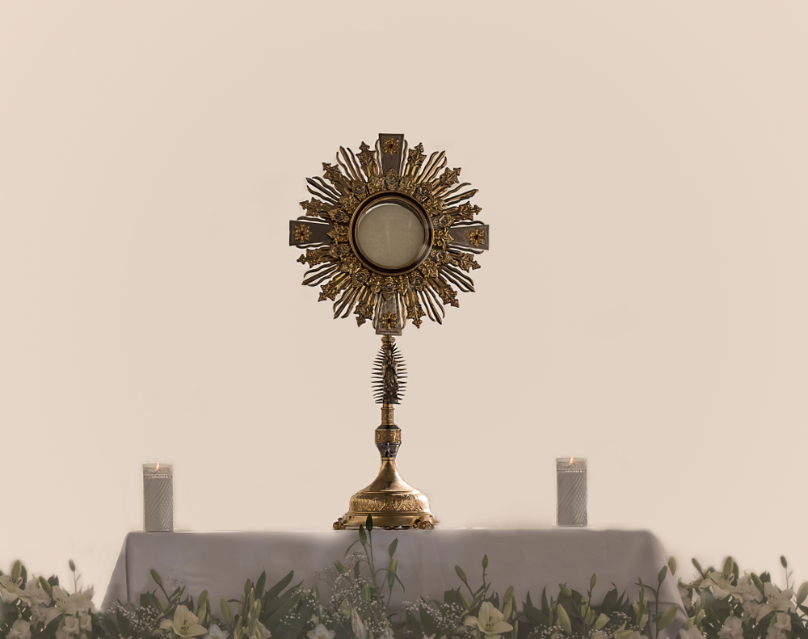

A monstrance displaying the holy sacrament, Christ’s real presence on Earth.

#### The Real Presence of Christ

Magical beliefs, however, cannot float entirely free of the rational norms that spontaneously arise from the necessity to materially reproduce society. Temple builders typically don’t summon demons but apply their knowledge of mechanics. In consequence, maintaining magical credulity requires some accommodation with the general stock of ordinary, non-magical beliefs about what exists and how things work.

The Eucharist — as a summoning, a sacrifice, and a union with the supreme being — is highly magical. It therefore stretches credulity and invites scepticism. The great intellects of Christianity have, over the ages, devoted considerable effort to reconciling its in-group mysteries with the profane knowledge of wider society.

The key challenge is to maintain the power of the Eucharist (deriving from the belief that Christ is actually present during the ritual) without exhausting credulity (deriving from the fact that Christ is actually not). Christian theorists oscillate between two extremes: inflationary interpretations — which claim that God is objectively and therefore miraculously present — and deflationary interpretations — which claim that God is subjectively and therefore mundanely present.

Complete deflation reduces Christ’s presence to a mere summoning to memory. On the upside, this is completely credible. On the downside the magical effect is correspondingly less intense.

Deflationists, in order to retain some magical power, may additionally claim that the bread and the wine are social symbols that refer to Christ, but not mundanely like a road sign, but miraculously in virtue of the power of God. The symbols objectively represent Christ, not merely because we believe it, but in virtue of God’s real presence, both as the Father and the Son. This is more magical, although its credibility is entirely circular.

Inflationary interpretations, on the other hand, propose that Christ is really present in the bread and wine. This is an ambitious claim. But inflationists are quick to emphasise that it would be theologically naive to think that any scientific experiment could in principle verify this presence. God forbid that God be tested by mere human intellects.

Instead, medieval theologians recruited the Aristotelian distinction between an invariant substance (e.g. a collection of H2O molecules) and its accidental properties (e.g. whether water is a liquid, solid or gas; whether hot or cold; whether transparent or opaque etc.) to account for the fact that the bread and wine, during the ritual, remains quite unchanged according to our senses. The divine manifestation, the actual hosting by the host, does not alter the accidental properties of the bread and wine but “transubstantiates” their underlying substance. But we can only sense accidental properties so this change is inaccessible to us. As some theologians courageously point out, Christ’s statement that “this is my body” does communicate a “statement of fact” but not one “of the empirical order”.

Inflationary interpretations clearly have greater magical power. So powerful that the magic can break through into accessible reality.

The Feast of Corpus Christi, which celebrates the Real Presence of Christ, was inaugurated by Pope Urban IV in 1264 in response to the miracle of a consecrated host leaking actual blood onto a cloth. In the 20th century, traces of myocardium tissue were found in consecrated bread that showed signs of stress consistent with death due to traumatic crucifixion. And the magic of the Eucharist very occasionally extends even to the lowly animals. The 13th Century Dialog on Miracles reports that bees created a shrine to Christ after sacramental bread was placed in their beehive.

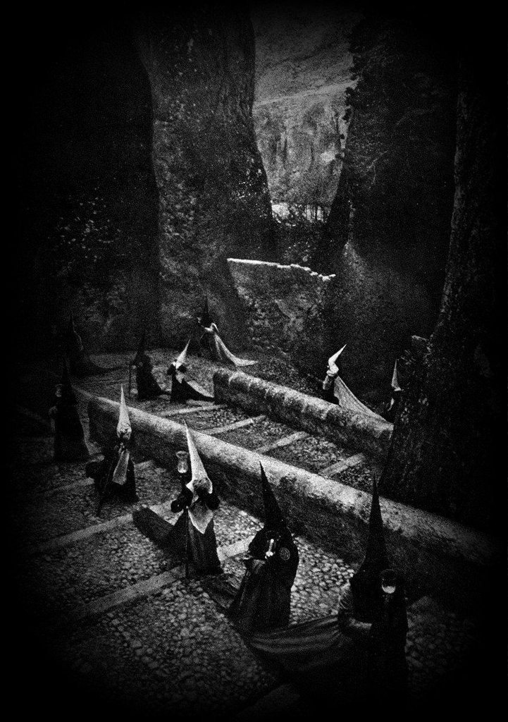

#### A Spiral of Spiritual Production

Regardless of the theological subtleties, the Eucharist yields a fruit, an output, a product, which has a dual, or two-fold character. On the one hand, it is bread and wine; on the other, the flesh and blood of Christ, either substantially or referentially. The extraordinary product of the Eucharist is nothing less than the substance of God, the supreme being, but in a sacrificed state.

The faithful consume the divine substance to bond with the Christian community in familial love and unite intimately with Christ and receive spiritual nourishment and redemption, which is the fruit of his original sacrifice on the cross. Christ stated that:

> “Whoever eats my flesh and drinks my blood has eternal life, and I will raise him on the last day.”

> John 6:54

So the Eucharist also promises a kind of immortality. This divine substance, in virtue of its magical powers, has been in high demand for roughly two millennia.

But the Eucharist isn’t merely a self-reproducing cycle of production, distribution and consumption of a divine substance. The Eucharist is intended to be performed on ever increasing scales. Christ gave his disciples the power to command demons and instructed them to go forth and baptize all nations. Christianity grew rapidly from a small Jewish cult to become the official religion of the Roman Empire and then to dominate the spiritual life of medieval Europe. The mission of Christ’s Church is to spread the gospel, that is the good spell, to all of humanity, and observe the Eucharist on greater and greater scales, thereby summoning greater quantities of the salvific substance into our material world, until, in the limit, on the last day, the whole of creation is filled with divine love, and saved and redeemed, in holy and eternal communion with God.

Mass participation in the Eucharist spirals humanity upwards towards the Good. The Eucharist is a magical solution to the problem of evil that has captured the imaginations of millions and significantly affected the course of human history.

The Eucharist is powerful magic indeed. However, it is a very puny thing compared to the immense magical power of the Dark Eucharist, which we will now turn to.

### Part Two: Dark Enchantment

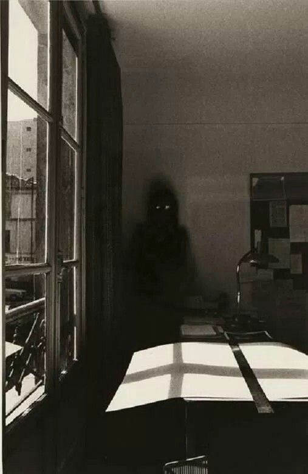

Linda Benedict-Jones -Time release, 1976

The moment of epiklesis, when summoning a spirit, may be experienced as a sudden revolution in the meaning of what is already empirically present. The shadow in the corner, which you watched with growing fear, stirs imperceptibly, to reveal a substantial form. The “horrors beyond life’s edge” exist, and exert their baleful influence, long before we notice them.

[figure not shown]

Peak Hour, by vergvoktre, 2014

#### Disenchantment

Capitalism, as it broke free from the feudal constraints of monarch and church, developed its own commercial culture where the ultimate judge was worldly success measured by profit. Of course, the bourgeoisie happily maintained any religious ideas consistent with capital accumulation. But in general the Enlightenment of the 18th century had a radically secular core.

The growth of industry meant more people with their heads down on the pragmatics of production. Everyone was busy with a new type of business. Eyes drifted less frequently upwards to ponder superlunary beings. And so magical world views became less relevant, and religion relegated to a few hours on Sunday.

The new field of social science, confident atop its bourgeois base, began to view religion and magic as cultural objects to study and compare, rather than ideas to live and die by. Social science even turned its attention to its own preconditions. The sociologist, Max Weber, viewed the commercialisation of society as a process of disenchantment, a triumph of the secular over the sacred.

Yet, as all magicians know, powerful magic can only be dispelled by more powerful magic. Capitalism’s focus on commercial success, and its pervasive scientific and instrumental rationality, cannot fully explain the death of God.

[figure not shown]

Friedrich Gilly, Design for the Royal Iron Mill, Berlin, 1797

#### A Spiral of Material Production

The science of economics is capitalism’s own account of its fundamental nature. It emerged as a distinct field of inquiry in the 18th and 19th centuries. From the outset, it was conceived primarily as a science of human behaviour subject to material constraints, such as the scarcity of land, labour and capital.

The classical liberal vision of a capitalist economy is that of a great exchange between people mediated by money and markets. At one end of the social organism people produce goods, at the other end people consume them. Market exchange connects and integrates the two poles. The laws of supply and demand ensure production adjusts to what consumers want. Those with capital hire labour at a fair market price when needed, and release labour to be deployed elsewhere when it’s not. Labour is therefore deployed correctly, although with unavoidable but temporary unemployment. The economy, driven by human wants and needs, adapts and grows via profit-rate signals that incentivise innovation and efficiency, which enables production at increasing scales. Of course, resource constraints cannot be abolished. Not everyone can have everything they want. At least not right away. But profit-seeking, hard work, and prudent saving for the future inexorably yields the fruits of increasing material wealth and spirals humanity upwards towards a final omega point of the universal satisfaction of all human desires.

A core belief of capitalist ideology is that we humans drive the system, that we are ultimately in control. The marginal turn in economic science, in the 19th Century, solidified around the vision of *homo economicus*, the rational individual that acts to optimise their self-interest. Neoclassical economics, in the 20th Century, proposed “representative agents”, which are single minds that aggregate the preferences of millions, with the power to steer national economies by maximising utility according to the axioms of rational choice theory. Yes, the state may need to intervene to uphold property rights. It may even need to break up a monopoly here and there. But in general we humans, when we self-organise through money and markets, control our own destiny and achieve optimal outcomes.

Humanity, in the enchanted worlds of classical antiquity and the middle ages, consorted with spiritual beings. Hence the long history of sacrificial exchanges between peoples and their gods. But capitalism has done away with the gods. In our disenchanted world the unmoved mover is our own human desires, not a hidden spirit. Economics envisions capitalism as a great secular exchange between humanity and itself. We face each other in the market, and nothing stands in between. We are sovereign individuals, free of feudal superstition, and free to buy and sell as we wish.

But free within constraints. We are all subject to the fundamental laws of economics that emerge from our collective behaviour. Resource scarcity cannot be abolished. We must therefore accept that almost everything we do is both enabled and constrained by the quantity of money at our disposal. Because the money in our pockets, we are told, is merely a local representation of this global scarcity. If you have very little, and your life is impoverished, that’s lamentable but not really preventable.

The secular vision of economics is consistent with many aspects of our everyday experience. But shadows loom on the edge of this vision that hint at other realities. The science of economics neglects that emergent laws must be enforced by emergent powers. Capitalism disenchanted the medieval world only by weaving its own new enchantment. But it is a dark enchantment that hides the existence of a great power of enforcement that lurks in the shadows. When we face each other in the market it stands between us, not as mediator of our desires, but as controller of them.

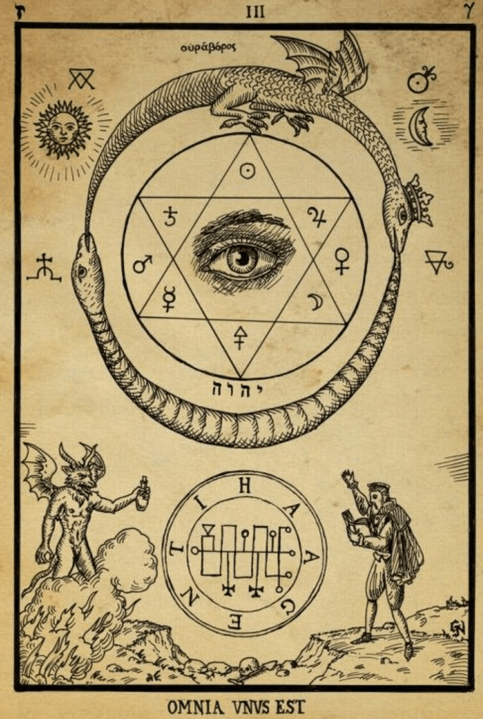

OMNIA VNVS EST

#### Egregores

We can begin to dispel the dark enchantment, and discern the outlines of the great power that lurks in the shadows, once we realise that our economic activities do not instantiate mere economic laws but entire feedback control loops that function as semi-independent entities that control the activities of their own human substrate. Egregores, not merely economic laws, supervene upon our social practices.

An egregore is an entity that exists in virtue of the collective ritual activities of a group yet operates autonomously, according to its own internal logic, to materially influence and control the group’s activities. The group creates the egregore, and the egregore creates the group, in a self-reinforcing feedback loop.

As [Edmund Griffiths](https://link.springer.com/book/10.1057/9781137346377) points out, we take the existence of mundane beings — such as people, animals, plants, and so on — for granted. But religions typically propose the existence of extraordinary beings. Such propositions form part of the core beliefs of the religious system and are charged with emotional affect. For instance, all gods are personified egregores that their followers believe exist independently of them.

Christ, for example, is one of the egregores of the Christian faith, believed to be God literally personified as a human. This claim may be true or false. But the social reality of egregores, and their real effects, is quite independent of this judgement. In fact some egregores exist, without being known at all.

[figure not shown]

Recveil D’Emblemes Divers, Jean Baudoin, 1638

#### The Real Presence of the Real God

All modes of production need methods to organise labour and allocate resources. But Marx, in his 1844 comments on James Mill, points out that, in capitalism, this necessity takes an unnecessarily alienated form. And by alienated he means taken out of our hands and given over to something not under our conscious control.

Marx states that, in capitalist society, our economic activities are controlled by an actual entity, a “real God”, with real causal powers. And Marx laments that we have become slaves to this god and its cult has become an end in itself. In other words, the social relations of capitalism summon forth an egregore.

How? Capitalism is a social system dominated by competing private capitals. A private capital is not merely a large sum of money but a feedback control system entirely oriented towards profit maximisation. Capitalists, as temporary owners of capital, must seek out profit or see their capital diminish and risk being thrown down into the ranks of waged workers. And waged workers must seek out capitals willing to hire their labour. The laws of capitalist competition, which are an unintended consequence of our particular methods of organisation, compel us all to behave in certain ways — and therefore partially create the kind of beings that we are. The humans in the loop, both the workers making and the capitalists taking, dutifully perform their allotted social roles, like enchanted rag dolls.

Capitals are born, combined, split, and die. Many are small, extracting profit from a handful of waged labourers; a few are astronomically large, extracting profit from hundreds of millions. Capitals can persist over multiple generations, outliving their temporary human vehicles.

Each private capital manically scrambles for profit by reacting to profit-rate signals from every productive activity that can be owned, dispensing monetary rewards and punishments, injecting funds into profitable activities and withdrawing funds from those that are not. In consequence, the entirety of the world’s material resources, including the working time of billions of people, are repeatedly marshalled and re-marshalled away from low and towards high-profit activities.

Marx’s Real God, which he names “capital”, is an egregore summoned into being by every circuit of capital accumulation. The egregore is a semi-autonomous entity with its own primitive form of cognition: it wants profit, it senses the presence and absence of profit, and then it acts in its world to get more profit.

Our earliest theories of how the world works were animistic. The God of the Old Testament became angry and punished Israel with pestilence. Modern science rejects this anthropomorphism and instead explains empirical regularities, whether natural or social, in terms of laws. But laws, properly understood, are descriptions of the causal powers of things. The important truth of archaic animism is that our world is indeed populated with things with their own powers that exist independently of us.

Marx’s Real God is just such an entity. It is a real presence amongst us. Its imperatives possess our minds and dictate our actions. It is not made of flesh and bones. It has a purely social reality. Nonetheless, this bloodless animism has bloody consequences.

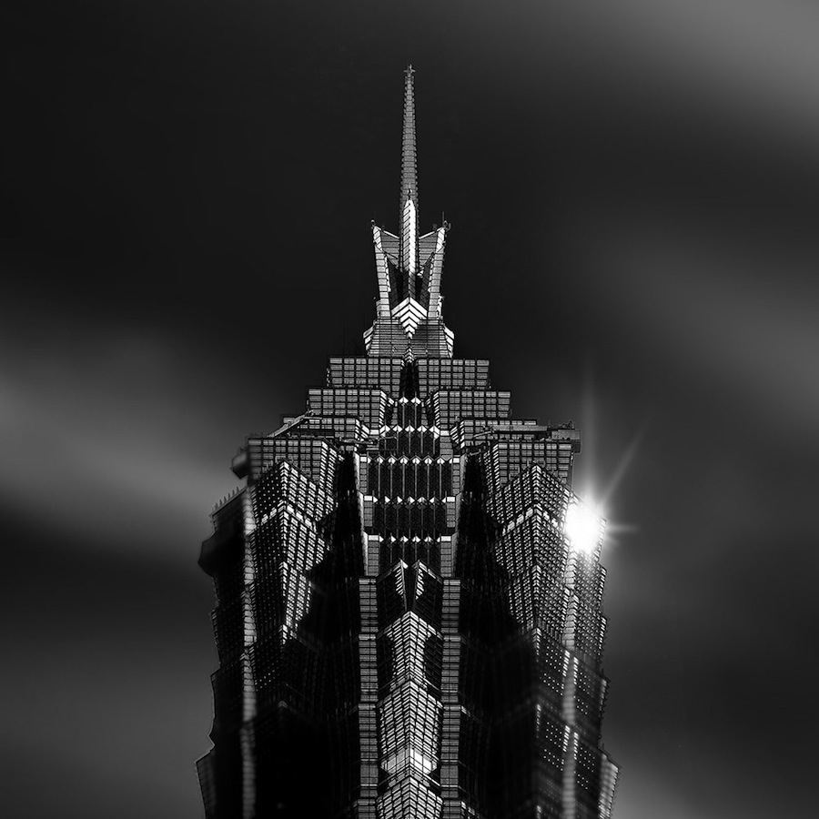

Jin Mao Tower, Shanghai

#### An Occult Mode of Production

Christ’s church celebrates his real presence during the Eucharist. But capitalism neither celebrates or personifies its Real God. In fact, its egregore is so thoroughly occulted it still lacks a complete theoretical expression and therefore a proper name.

The Real God is hidden for two main reasons. First, what exists is not immediately disclosed by direct experience. We must perform scientific work to uncover the hidden social mechanisms that govern our lives. Capitalism’s egregore is a consequence of our social relations and therefore is objectively hidden. Its singular and enduring existence must be inferred from the plurality of its empirical effects. And it wasn’t until the Marxist heresy of the 19th Century that this inference first reached maturity.

The second reason is more magical, and therefore more a matter of imagination. The etymological root of the word religion is to bind, to create an obligation between humans and a god. All religions bind their communities. So we should expect structural similarities between religious and economic practices because they both organise and integrate communities.

Any social institution needs a good news story to give meaning to its rituals. Christ is worshipped for his message of salvation. However, capitalist ideology, to preserve its magical power, must deny its own god, otherwise it risks unbinding its community. *The knowledge that the world is controlled by an alien entity — which converts every labour-saving innovation into the iron necessity to work even more, which outrageously rewards those few it possesses with power and riches while leaving the majority dispossessed, which corrupts democracy and prevents it in our workplaces, which captures the great power of the state to enlarge its domain, discipline the poor and suppress opposition, which drives nations dominated by large capitals to compete to exploit those dominated by smaller capitals, including waging bloody imperial wars of conquest and ruin, which rewards the plundering of the natural world without replacement, and which constrains our collective political imagination to perpetually subsist within the narrow bounds of lamenting but not preventing the human misery it blindly creates — such knowledge must be utterly and thoroughly repressed.* For if more of us knew that it just doesn’t have to be this way, that every one of these social ills, and more, is not a necessary consequence of human intercourse but an unnecessary consequence of the dictatorship of Capital, then the dark enchantment would dispel and the true horror would step forth from the shadows.

Capitalist ideology celebrates a radical and progressive break from feudal paternalism and superstition. Before we believed in gods and magic. But now we are modern and rational. Universal commodification and the private pursuit of profit delivers the goods. This is powerful magic but the panglossian assertions lose credibility when confronted by our lack of control, our repeated inability to change anything for the better. The power-credulity trade-off must therefore be managed.

Bourgeois economics suppresses the Marxist heresy. But widespread failures to deliver the goods still need to be accounted for. Economic science has developed an elaborate theodicy, with a range of theoretical options to suit different levels of tolerance for the incredible, which redirects the blame for social ills onto anything but the existence of the rule of capital. Austrians blame the fall from grace on the lack of hard money. The evil state corrupts by issuing currency by fiat. Neoclassicals trumpet welfare theorems that prove that capitalist competition is a perfect mechanism that delivers optimum outcomes, if only capital was given full reign to commodify everything under the sun. Keynesians, more credibly, admit that unfettered capitalism has problems of coordination and distribution, but less credibly propose that bourgeois politicians, possessed representatives of the Real God, will fix them.

The glamour is strong but wavers in the corner of our eye. We catch glimpses from beyond the veil: capitalists earning more in one night’s sleep than workers do from a lifetime of wages; rich countries with persistent homelessness and yet unused bricks, land, and unemployed construction workers; families hungry in the context of abundant food. Economists are unconscious magicians, for they authentically believe what they preach, and their words of power continually re-weave the dark enchantment by maintaining incredible beliefs in the intrinsic goodness of the rule of capital.

Capitalism does not transcend religion. It is merely its inverted opposite. We have not yet rid ourselves of spirits, gods and demons. Our world remains enchanted, but darkly. Capitalism is an occult mode of production with a hidden god and a Dark Eucharist. For any sufficiently advanced religion is indistinguishable from economics.

### Part Three: The Magic of the Dark Eucharist

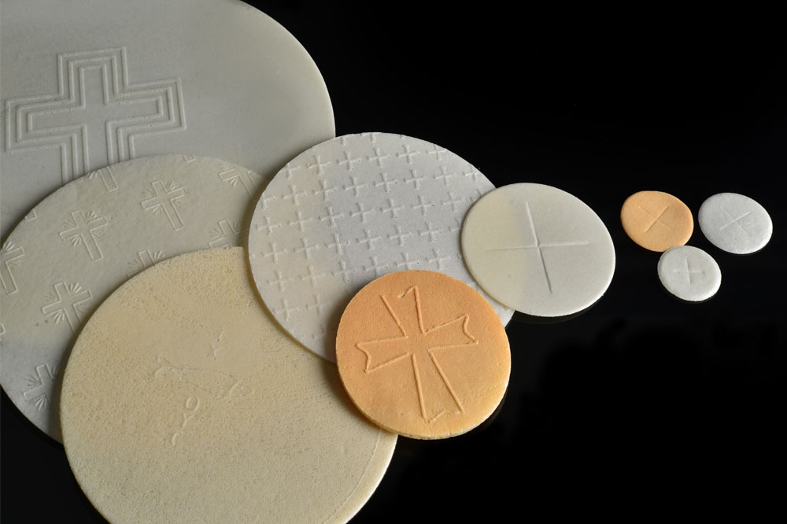

Hosts and Particles

#### Marx on Money and Christ

Marx, in his [comments on Mill](https://www.marxists.org/archive/marx/works/1844/james-mill/), after stating that capitalism is a new kind of cult that worships a Real God, immediately reflects on the strange affinities between Christ and money. Marx writes:

> “Christ represents originally: 1) men before God; 2) God for men; 3) men to man.”

This is an elliptical statement. But Marx suggests that Christ is a multivocal symbol that mediates how humanity relates to itself and to God. The thesis is Christ as an ordinary man, like all of us, humble before God. The antithesis is Christ as God incarnate who loves His creation. The synthesis, which transcends the contradiction, is the Church, our human community and Christ’s mystical body, which binds us together in a holy communion mediated by God.

Next Marx applies this same template to money:

> “Similarly, money represents originally, in accordance with the idea of money: 1) private property for private property; 2) society for private property; 3) private property for society.”

Marx suggests that money is Christ-like for it too is a multivocal symbol that mediates how humanity relates to itself and to its property. The thesis is money as a symbol of the value of our individual property. The antithesis is money as the social incarnation of property in general. The synthesis is the ritual of market exchange that binds humanity together in a material communion mediated by money.

But Marx is not yet finished. Although Christ and money are mediating symbols that bind a community they are also social symbols that are quasi-independent of us, and above us. The integration they achieve is incomplete, part real, but part illusory and therefore magical. Marx writes:

> “But Christ is alienated God and alienated man. God has value only insofar as he represents Christ, and man has value only insofar as he represents Christ. It is the same with money.”

“It is the same with money” because money is an alienated symbol of our own powers. And in a society ruled by its alien mediator, the Real God, both the social and the personal only have value, only represent the Good, insofar as they represent money. We use social symbols to mediate our relations. But we become mere symbols for the mediator. And in these abstractions we lose something of ourselves, and become enchanted.

[figure not shown]

Eye on Skulls

#### The Sacrificial Orgy

*The Dark Eucharist is the origin of profit in the sacrifice of our labour as tribute to the Real God.* And like the Christian Eucharist it is simultaneously a summoning, a sacrifice and a union.

Money has many different material forms, such as precious metal, or coins or notes, or numeric entries in a database. But these material forms are mere vehicles for the unit of account, economic value itself, which is a social symbol. Bourgeois economics long gave up the attempt to fully decipher this social hieroglyphic and has converged to almost complete silence on the question. We’re told that the unit of account is a quantity without quality, a token of nothing, a symbol that does not symbolise. But money has an esoteric content because, in the Dark Eucharist, it functions as the host.

Every capitalist firm is a house of god, a site of tribute to capital. Workers, in their daily ritual, sacrifice their labour to produce useful things for others. But the real aim is a hoped-for fruit, a divine yield, a profit. So not any sacrifice will do. The sacrifice must be sufficiently efficient and useful that the product, when sold, yields an excess, a shining sum of money profit. Profit is the moment of epiklesis when more of the salvific substance is summoned into the world.

All the individual rituals form part of one great ritual. And all the individual capitals are merely a thousand faces of the same god. A necessary condition for the success of the great ritual is that workers truly sacrifice themselves. This cannot be a mere exchange with god; it must be a tribute, a genuine giving up. For profit in the aggregate is only possible if workers collectively sacrifice more of their time to capital than they receive in the form of the goods and services they consume.

The Real God is an entity that manipulates a particular feature of the world via money flows in order to achieve control success, which is more profit. That feature is our collective labour willing and able to sacrifice itself. Money is therefore both an aspect of the Real God’s presence and a representation of our own labour powers. In the Eucharist ordinary bread and wine represent Christ in virtue of the actions of the Holy Spirit. In the Dark Eucharist money represents sacrificed labour in virtue of the actions of the Real God. *Money is the symbolic union of humanity with its god.*

The money profit, as the substantial presence of the Real God, inherits divine power. Money is the universal use-value, the universal Good, able to make our wishes come true. We all desire to possess it, to hold it, to commune with it, for we are lost souls without it.

The capitalists, as orchestrators of the sacrificial rite, divide and share out its fruit. This substance is so precious that not a drop can be spilled or lost. Even the smallest fraction must be accounted for. Its subsequent distribution to the assembled faithful is a carefully controlled affair, subject to strict rules. The poorer cuts are distributed to the workers who receive the boon of a wage. But the best cut is reserved for capital. Each Dark Eucharist augments the power of the Real God, enabling it to command a greater share of our products, to extend its private domain through the ownership of more productive assets, to enclose more and more of the world as its private property, and attract greater numbers to join the sacrifice. Our tribute increases the power of capital and deepens our servitude to it. For beneath the apparent chaos of market prices, and the fluctuations of supply and demand, is a simple order. All the prices of all the things in the world, and all the wages, are always such to prevent workers saving sufficient quantities of the divine substance to enjoy more free time. *The Real God prevents its subjects from controlling how long they work by collectively deciding on the rate of economic growth and the length of the working day.* The salvific fruit cannot be saved, and therefore cannot truly save us, for it flows back to capital itself, to increase its power of command. The simple and universal underlying order is: sacrifice yourself, forever.

In consequence, the money in our pockets does not only represent necessary scarcity. The distribution of monetary wealth, and the structure of prices, also represents our unnecessary servitude, our collective kneeling down in worship of a fetish. The money wage is a reward for sacrifice that compels further sacrifice. Disenchantment is a myth, itself part of the dark enchantment. For a god abides with us still. And if we wish to see its face we need merely reach into our own pockets.

We yield up and offer nothing less than our living activity. There is no greater gift we could give. We sacrifice fractions of our living essence, our unique and finite being, every single working day, until eventually we have nothing left and our health fails. And then we are fully spent, entirely transubstantiated into the private property of our Dark Lord and Master.

[figure not shown]

The Resurrection by the Pericle Fazzini, 1965 (the Paul VI Audience Hall)

#### Triumph of the Demiurge

The Christian Eucharist aims to unite humanity in familial love, to care for the sick, the needy and the poor, and lead us to salvation from the ills of this world. The utopian aspirations of Christianity, there from the beginning, and still with us now, express some of humanity’s deepest and most noble aspirations.

Christ chose bread and wine to share because these are goods we want: one subsistence, another luxury — a perfect representation of our material aspirations. Christ did not choose money. He remarked that:

> “No one can serve two masters. Either you will hate the one and love the other, or you will be devoted to the one and despise the other. You cannot serve both God and money.”

> Christ, Matthew 6:24

Christ understood that money was already spoken for, that it already hosted a host.

The Christian God turned out to be powerless before the historic rise of the Real God. Today, a large capital looms above the performance of every Christian ritual. All denominations prudently manage their portfolio of investments searching for a wholly different kind of divine yield, quite content to share in the sacrificial spoils of the Dark Eucharist. Christ’s ejection of the money lenders from the temple, the medieval proscriptions against usury, the attempts to define and impose just prices, the angry denials that money can be fruitful, are largely forgotten, faint echoes from a time before the triumph of the demiurge. Christianity has made its uncomfortable peace with capital, and bowed to its rule, often standing shoulder-to-shoulder with those driven mad by the Real God’s insatiable appetite, giving its blessings to colonial conquest, slavery and imperial war, liberating souls for one god while liberating gold for another.

The Dark Eucharist, performed daily by billions of workers across the globe, transubstantiates our sacrifices into the corporeal body of a hidden God. The Dark Eucharist, unlike the Christian ritual, does not unite humanity in love but divides us into an anointed elite, the exploiting class, and a sacrificial flock, the exploited class. During the ritual the Real God does not sacrifice itself in love for us and neither grants wishes at our command. This is a new kind of magic, neither Christian or Solomonic. Instead, the Real God consumes our flesh and blood, uses-up our living activity, and thereby acquires our powers for itself. A universal dark enchantment conceals the fundamentally idolatrous and sacrificial nature of the capitalist mode of production. We blindly worship a blind God. And the true meaning of money — as the Real Presence of the Real God in our lives — remains occulted.

Capitalist society is, as Marx wrote, “like the sorcerer who is no longer able to control the powers of the nether world whom he has called up by his spells.” Perhaps the greatest bourgeois myth, the height of its hubris and the essence of its magical power, is the belief that capitalism is a secular and rational mode of production. But a deep unacknowledged continuity exists between capitalism and its enchanted precursors. Capitalism is an occult mode of production controlled by a hidden God that manipulates its subjects to engage in great orgies of unnecessary sacrifice and ecstasies of blind accumulation. We may live in an Age of Reason but the Reasons are not our own. The great sacrificial exchanges between a people and its god are not overcome by capitalism but reproduced in a new and more universal form. We will therefore remain not yet modern, wandering lost in the dark ages of humanity, until we throw off our dark enchantment, dare to look into the depths of the black mirror and confront the horror we have summoned forth.

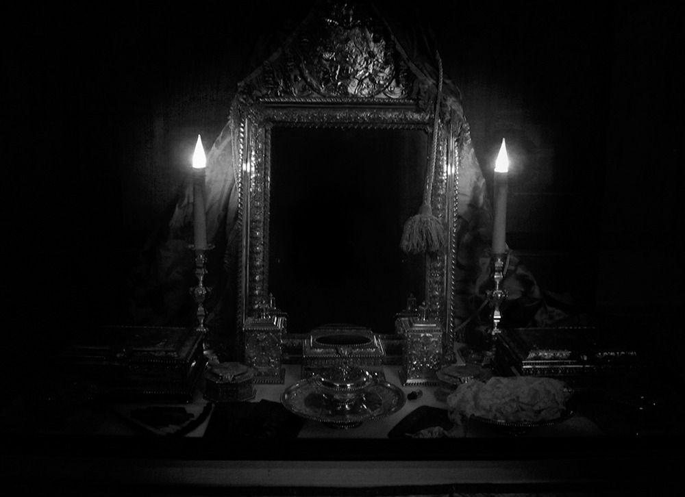

#### Further Reading

- [Comments on James Mill](https://www.marxists.org/archive/marx/works/1844/james-mill/), Karl Marx
- [The Fetishism of Commodities and the Secret thereof](https://www.marxists.org/archive/marx/works/1867-c1/ch01.htm#S4), Karl Marx
- [Fossil Angels](https://glycon.livejournal.com/13888.html), Alan Moore
- [Towards a Science of Belief Systems](https://link.springer.com/book/10.1057/9781137346377), Edmund Griffiths
- [Techniques of Solomonic Magic](https://www.amazon.co.uk/Techniques-Solomonic-Magic-Stephen-Skinner/dp/0738748064), Stephen Skinner.
- [Capitalism as Religion](https://cominsitu.wordpress.com/2018/06/08/capitalism-as-religion-benjamin-1921/), Walter Benjamin.
- [Enchantments of Mammon](https://www.hup.harvard.edu/catalog.php?isbn=9780674984615), Chapters 1 and 2, Eugene McCarraher.
- [On Capital and Labour](https://www.vatican.va/content/leo-xiii/en/encyclicals/documents/hf_l-xiii_enc_15051891_rerum-novarum.pdf), Encyclical of Pope Leo XIII.
[^1]: https://www.marxists.org/archive/marx/works/1844/james-mill/
[^2]: https://www.marxists.org/archive/marx/works/1867-c1/ch24.htm
[^3]: https://www.marxists.org/archive/marx/works/1848/communist-manifesto/ch02.htm
[^4]: https://www.marxists.org/archive/marx/works/1848/communist-manifesto/ch01.htm
[^5]: https://www.marxists.org/archive/marx/works/1867-c1/ch24.htm
[^6]: https://www.marxists.org/archive/marx/works/1877/anti-duhring/ch27.htm
[^7]: Ibid.
[^8]: https://papers.ssrn.com/sol3/papers.cfm?abstract_id=2262133